# Seed-labeling campaign QC and near-duplicate validation

Two things are measured here, and they share a theme: **a design that could be audited before it produced any data, and can now be audited against the data it produced.**

The first is the **seed-labeling campaign** (stage s07). 12,000 prompts are drawn from the universe, stratified by source × size band, with a deficit-redistribution rule for sources that cannot fill their quota. 100 of them become a calibration batch that a human revises by hand; the remaining 11,900 are sliced into batches of 77 new items plus **3 gold items carrying no mark of any kind** in the file handed to the annotator — which of the 80 are gold lives only in the manifest, because marking them would measure an agent's care on three items rather than the quality of the batch. Agreement is scored on `task_type` and `domain` of those 3 golds, so six comparisons at a granularity of 1/6, and the gate is 0.80 — five of six. The `manifest.json` is the campaign's **versioned ledger**: it is the one file in the labeling tree that is committed, precisely so that the design is inspectable before, during and after the run.

The campaign has since run in part, and this page reflects whatever the ledger says on the day it was rendered. The remaining batches are optional by an earlier decision: doubling the label count moved the classifier's macro-F1 by about a hundredth, so the ceiling turned out to be the recipe rather than the volume.

The second is the **near-duplicate validation** of stage s06, which has also run, and whose output on disk supports an exact invariant check.

**Read-only, and no prompt text.** Both `labeling/seed/seed.parquet` and `labeling/batches/*.json` carry full prompt bodies and are gitignored for that reason. This notebook reads the seed's *metadata columns only* — it never loads the `text` column — and renders counts and distributions. It also **withholds the gold labels themselves**: the hand-revised answer key is what every batch is scored against, and printing it here would let a reader recover agreement by elimination.

```python
# O backend TEM de ser o `inline`: ele é headless (renderiza por baixo com o
# mesmo Agg) E devolve a figura como saída da célula, que é o que o nbconvert
# embute no HTML. `matplotlib.use("Agg")` puro faz `plt.show()` virar no-op — o
# notebook executa limpo, sai com código 0 e produz um HTML sem UM gráfico.
%matplotlib inline
import base64
import io
import json
from collections import Counter
from html import escape as escape_html

import matplotlib
import matplotlib.pyplot as plt
import pyarrow.parquet as pq
from IPython.display import HTML, display

# png e não svg: o histograma do near-dup tem dezenas de milhares de patches, e
# em svg o HTML commitado sairia com megabytes de vetor.
%config InlineBackend.figure_formats = ["png"]

from prompt_factory import paths, schema

AZUL, LARANJA, CINZA, VERDE, VERMELHO = "#2f6f9f", "#d98032", "#8c8c8c", "#4a8c5f", "#b04a4a"
plt.rcParams.update({
    "figure.dpi": 110, "savefig.dpi": 110, "font.size": 10,
    "axes.titlesize": 11, "axes.titleweight": "bold", "axes.labelsize": 10,
    "axes.spines.top": False, "axes.spines.right": False,
    "axes.grid": True, "grid.alpha": 0.25,
    "figure.facecolor": "white", "axes.facecolor": "white",
})


def mostrar(fig, alt):
    # A figura é embutida À MÃO, com o `alt` escrito por nós. `plt.show()` sob
    # `matplotlib.use("Agg")` é no-op (HTML sem gráfico nenhum, sem erro), e o
    # `display(fig, metadata={"image/png": {"alt": ...}})` desenha a figura e
    # descarta o alt — o bloco `data_png` do template `lab` do nbconvert não lê
    # essa chave. Emitir o <img> daqui mantém o alt real e o render em UM comando.
    buf = io.BytesIO()
    fig.savefig(buf, format="png")
    plt.close(fig)          # senão o backend inline redesenha a figura no fim da célula
    b64 = base64.b64encode(buf.getvalue()).decode("ascii")
    display(HTML(f'<img alt="{escape_html(alt, quote=True)}" '
                 f'src="data:…" '
                 f'style="max-width:100%;height:auto">'))


def anotar(ax, valores, ys, *, dx, fmt="{:,.0f}"):
    for v, y in zip(valores, ys, strict=True):
        ax.annotate(fmt.format(v), (v + dx, y), va="center", ha="left",
                    fontsize=8.5, color="#333")


# Flags de existência: nada aqui pode levantar. Um clone limpo tem o manifest e a
# taxonomia (versionados) e NÃO tem a semente nem os parquets (regeneráveis).
SEED_PARQUET = paths.SEED / "seed.parquet"
STRATA_TXT = paths.SEED / "strata.txt"
SEED_LABELS = paths.FINAL / "seed_labels.parquet"
NEAR_MAP = paths.FINAL / "dedup_near_map.parquet"
EXACT_MAP = paths.INTERIM / "dedup_exact_map.parquet"
UNIVERSE = paths.FINAL / "universe.parquet"
DEDUP1 = paths.INTERIM / "dedup1.parquet"
NORMALIZED = paths.INTERIM / "normalized.parquet"
LANG_PARQUET = paths.INTERIM / "lang.parquet"

print("matplotlib backend:", matplotlib.get_backend())
assert "inline" in matplotlib.get_backend().lower(), (
    "backend sem captura de figura: o HTML sairia sem gráfico nenhum")

TEM_MANIFEST = paths.LABEL_MANIFEST.exists()
manifesto = json.loads(paths.LABEL_MANIFEST.read_text(encoding="utf-8")) if TEM_MANIFEST else {}
taxonomia = schema.load_taxonomy()

for rotulo, caminho in (
    ("labeling/manifest.json", paths.LABEL_MANIFEST),
    ("labeling/taxonomy.json", paths.TAXONOMY_JSON),
    ("labeling/seed/seed.parquet", SEED_PARQUET),
    ("labeling/seed/strata.txt", STRATA_TXT),
    ("data/final/seed_labels.parquet", SEED_LABELS),
    ("data/final/dedup_near_map.parquet", NEAR_MAP),
    ("data/interim/dedup_exact_map.parquet", EXACT_MAP),
    ("data/final/universe.parquet", UNIVERSE),
):
    marca = "ok     " if caminho.exists() else "ABSENT "
    tam = f"{caminho.stat().st_size:>13,} bytes" if caminho.exists() else ""
    print(f"  [{marca}] {rotulo:<38} {tam}")

print(f"\ntaxonomy v{taxonomia['version']}: "
      f"{len(taxonomia['task_type'])} task types, {len(taxonomia['domain'])} domains, "
      f"{len(taxonomia['flags'])} flags")
```

```
matplotlib backend: inline
  [ok     ] labeling/manifest.json                        78,460 bytes
  [ok     ] labeling/taxonomy.json                        21,033 bytes
  [ok     ] labeling/seed/seed.parquet                 6,455,268 bytes
  [ok     ] labeling/seed/strata.txt                       1,630 bytes
  [ok     ] data/final/seed_labels.parquet               312,562 bytes
  [ok     ] data/final/dedup_near_map.parquet            541,834 bytes
  [ok     ] data/interim/dedup_exact_map.parquet         422,972 bytes
  [ok     ] data/final/universe.parquet              301,519,520 bytes

taxonomy v1.0: 16 task types, 16 domains, 2 flags
```

## 1. The campaign design, as actually laid out

Quotas are planned per source, then reconciled against what the universe can actually supply. A source that cannot fill its quota **cedes the deficit** to the others in proportion, and every cession is written into `strata.txt` and into the manifest's `allocation.notas` — so the design is not a plan that diverged silently from the artifact, it is a plan whose divergences are part of the artifact.

The `oasst` row is the case that makes this a normal path rather than an exception: a quota of 600 against far fewer available rows in the universe.

```
seed size: 12,000   rng_seed: 42   size bands (chars): [120, 600]   truncation for the agent: 1900 chars
```

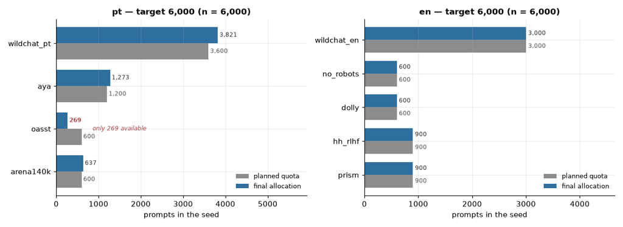

```
  [pt] rodada 1: oasst cede 331 (cota 600, disponível 269)
  [pt] rodada 1: wildchat_pt recebe +221
  [pt] rodada 1: aya recebe +73
  [pt] rodada 1: arena140k recebe +37
```

```python
if TEM_MANIFEST:
    aloc = manifesto.get("allocation", {})
    print(f"seed size: {manifesto.get('n_seed'):,}   rng_seed: {manifesto.get('seed_rng')}   "
          f"size bands (chars): {manifesto.get('bucket_edges')}   "
          f"truncation for the agent: {manifesto.get('truncate_chars')} chars")

    fig, axes = plt.subplots(1, len(aloc), figsize=(11.5, 4.2))
    axes = axes if len(aloc) > 1 else [axes]
    for ax, (lang, bloco) in zip(axes, aloc.items(), strict=True):
        fontes = list(bloco["final"])
        y = range(len(fontes))
        planejado = [bloco["planejado"].get(f, 0) for f in fontes]
        final = [bloco["final"].get(f, 0) for f in fontes]
        disponivel = [bloco["disponivel"].get(f, 0) for f in fontes]
        alt = 0.38
        b1 = ax.barh([i + alt / 2 for i in y], planejado, alt, color=CINZA, label="planned quota")
        b2 = ax.barh([i - alt / 2 for i in y], final, alt, color=AZUL, label="final allocation")
        for i, (p, f_, d) in enumerate(
                zip(planejado, final, disponivel, strict=True)):
            ax.annotate(f"{p:,}", (p + 40, i + alt / 2), va="center", fontsize=8, color="#555")
            ax.annotate(f"{f_:,}", (f_ + 40, i - alt / 2), va="center", fontsize=8,
                        color=VERMELHO if f_ < p else "#333",
                        weight="bold" if f_ < p else "normal")
            if d < p:                       # a fonte que não conseguiu encher a cota
                ax.annotate(f"only {d:,} available", (max(p, f_) + 260, i),
                            va="center", fontsize=8, color=VERMELHO, style="italic")
        ax.set_yticks(list(y), fontes)
        ax.invert_yaxis()
        ax.set_xlim(0, max(planejado + final) * 1.55)
        ax.set_xlabel("prompts in the seed")
        ax.set_title(f"{lang} — target {sum(final):,} (n = {sum(final):,})")
        ax.legend(loc="lower right", frameon=False, fontsize=8.5)
    plt.tight_layout()
    mostrar(fig, "Two panels, Portuguese and English, each a horizontal bar chart comparing the planned quota with the final allocation per source, flagging sources that could not fill their quota.")

    for lang, bloco in aloc.items():
        for nota in bloco.get("notas", []):
            print(f"  [{lang}] {nota}")
    if not any(b.get("notas") for b in aloc.values()):
        print("  no deficit redistribution was needed.")
else:
    print("skipped — labeling/manifest.json absent (run `pf make-seed`)")
```

### The gold slots, and why they carry no mark

Each batch hides 3 gold items among its 80. They are drawn from the hand-revised calibration batch and **re-sampled across batches**, so the same gold uid reappears in several batches — which is what makes agreement comparable between annotators who never shared a batch.

The reuse is deliberately uneven, and the histogram below shows the actual shape. What it buys: a gold item seen once measures one batch; a gold item seen thirteen times becomes a reference point that any two annotators can be compared through.

The file handed to an annotator contains only `uid`, `lang` and `text` for all 80 items — identical fields for gold and non-gold. Which three are gold lives in `manifest.gold_uids`, on the server side.

```
155 batches x 3 gold = 465 gold slots, filled by 99 distinct uids
mean reuse 4.70x   min 1x   max 13x
```

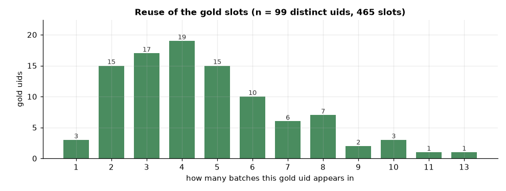

```
batch sizes  : 45 items x1, 80 items x154
new per batch: 42 new x1, 77 new x154
new items across all batches: 11,900 (+ 100 in the calibration batch = 12,000 of 12,000 seed items)
```

```python
if TEM_MANIFEST and manifesto.get("batches"):
    lotes = manifesto["batches"]
    reuso = Counter()
    for lote in lotes.values():
        for uid in lote.get("gold_uids", []):
            reuso[uid] += 1
    vagas = sum(reuso.values())
    distintos = len(reuso)
    print(f"{len(lotes)} batches x {manifesto.get('gold_per_batch')} gold = {vagas} gold slots, "
          f"filled by {distintos} distinct uids")
    if distintos:
        print(f"mean reuse {vagas / distintos:.2f}x   min {min(reuso.values())}x   "
              f"max {max(reuso.values())}x")

    hist = Counter(reuso.values())
    xs = sorted(hist)
    ys = [hist[x] for x in xs]
    fig, ax = plt.subplots(figsize=(9, 3.4))
    barras = ax.bar([str(x) for x in xs], ys, color=VERDE, width=0.72)
    for b, v in zip(barras, ys, strict=True):
        ax.annotate(str(v), (b.get_x() + b.get_width() / 2, v), ha="center",
                    va="bottom", fontsize=8.5, color="#333")
    ax.set_xlabel("how many batches this gold uid appears in")
    ax.set_ylabel("gold uids")
    ax.set_title(f"Reuse of the gold slots (n = {distintos} distinct uids, "
                 f"{vagas} slots)")
    ax.set_ylim(0, max(ys) * 1.18)
    plt.tight_layout()
    mostrar(fig, "Bar chart histogram of how many batches each distinct gold uid appears in.")

    tam = Counter(lote.get("n_items") for lote in lotes.values())
    novos = Counter(lote.get("n_novos") for lote in lotes.values())
    print("batch sizes  : " + ", ".join(f"{n} items x{c}" for n, c in sorted(tam.items())))
    print("new per batch: " + ", ".join(f"{n} new x{c}" for n, c in sorted(novos.items())))
    total_novos = sum(n * c for n, c in novos.items())
    print(f"new items across all batches: {total_novos:,} "
          f"(+ {manifesto['calibration']['n_items']} in the calibration batch "
          f"= {total_novos + manifesto['calibration']['n_items']:,} of "
          f"{manifesto['n_seed']:,} seed items)")
else:
    print("skipped — no batches in the manifest")
```

## 2. Campaign status

`agreement` is `None` on a batch that has not been scored, and `None` is **not** `0.0`. Before any gold has been imported there is no measurement at all, and rendering the absence as a zero would fail the whole campaign on a number nobody computed. The same distinction appears in the reviewer calibration of the first notebook — it is the project's recurring rule about honest absence.

A batch bounced by the agreement gate keeps the score that failed it, but **leaves the average**: its work was discarded, so counting it would be scoring an annotator on output nobody kept.

```
82 of 155 batches done (53%)
    done           82  (53%)
    pending        73  (47%)

batches with an agreement score: 82 of 155
batches with agreement = None (not measured): 73

calibration batch `batch_0000`: 100 items, status = 'gold', revised_at = '2026-08-12T21:22:23Z'
manifest.gold (the imported hand-revised labels): 100 entries — the labels themselves are withheld from this page
```

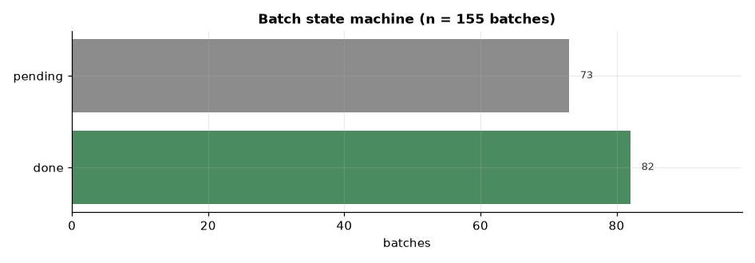

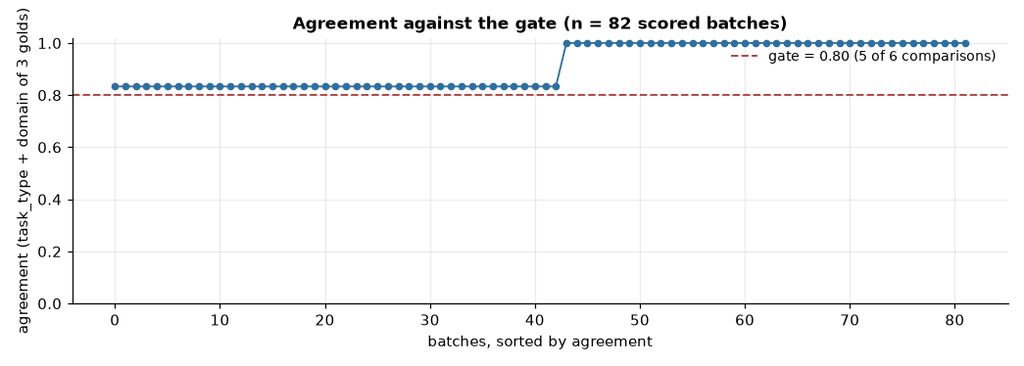

```
82 of 82 scored batches clear the 0.80 gate (100%)
mean agreement: 0.913  (granularity is 1/6 = 0.167; only 7 values are possible)
```

```python
if TEM_MANIFEST and manifesto.get("batches"):
    lotes = manifesto["batches"]
    estados = Counter(lote.get("status") for lote in lotes.values())
    total = len(lotes)
    feitos = estados.get("done", 0)
    print(f"{feitos} of {total} batches done ({feitos / total:.0%})")
    for st, n in estados.most_common():
        print(f"    {st!s:<12} {n:>4}  ({n / total:.0%})")

    notas = [lote["agreement"] for lote in lotes.values()
             if lote.get("agreement") is not None]
    sem_nota = total - len(notas)
    print(f"\nbatches with an agreement score: {len(notas)} of {total}")
    print(f"batches with agreement = None (not measured): {sem_nota}")

    cal = manifesto.get("calibration", {})
    print(f"\ncalibration batch `{cal.get('batch_id')}`: {cal.get('n_items')} items, "
          f"status = {cal.get('status')!r}, revised_at = {cal.get('revised_at')!r}")
    # O gabarito NÃO entra nesta página, e a contagem entra. São os rótulos
    # revisados à mão contra os quais TODO lote é pontuado: publicá-los num HTML
    # commitado permitiria acertar o agreement por eliminação, que é a mesma
    # razão pela qual o notebook 01 retém o alvo escondido de uma sintética ainda
    # não revisada. Enquanto `gold` era `null` esta linha não imprimia nada; hoje
    # imprimiria as 100 entradas inteiras.
    ouro = manifesto.get("gold") or {}
    if ouro:
        print(f"manifest.gold (the imported hand-revised labels): {len(ouro)} entries "
              f"— the labels themselves are withheld from this page")
    else:
        print("manifest.gold (the imported hand-revised labels): not imported yet")

    ordem = ["pending", "claimed", "done", "failed"]
    rot = [s for s in ordem if s in estados] + [s for s in estados if s not in ordem]
    val = [estados[s] for s in rot]
    fig, ax = plt.subplots(figsize=(8.6, 0.6 * len(rot) + 1.8))
    barras = ax.barh(rot, val, color=[VERDE if s == "done" else
                                      VERMELHO if s == "failed" else
                                      LARANJA if s == "claimed" else CINZA for s in rot])
    anotar(ax, val, range(len(rot)), dx=max(val) * 0.02)
    ax.invert_yaxis()
    ax.set_xlim(0, max(val) * 1.2)
    ax.set_xlabel("batches")
    ax.set_title(f"Batch state machine (n = {total} batches)")
    plt.tight_layout()
    mostrar(fig, "Horizontal bar chart of batches by state in the claim state machine: pending, claimed, done, failed.")

    if notas:
        limiar = 0.80
        aprovados = sum(1 for a in notas if a >= limiar)
        fig, ax = plt.subplots(figsize=(9.5, 3.4))
        ax.plot(range(len(notas)), sorted(notas), marker="o", markersize=4,
                linewidth=1.2, color=AZUL)
        ax.axhline(limiar, color=VERMELHO, linestyle="--", linewidth=1.3,
                   label=f"gate = {limiar:.2f} (5 of 6 comparisons)")
        ax.set_xlabel("batches, sorted by agreement")
        ax.set_ylabel("agreement (task_type + domain of 3 golds)")
        ax.set_ylim(0, 1.02)
        ax.set_title(f"Agreement against the gate (n = {len(notas)} scored batches)")
        ax.legend(frameon=False, fontsize=9)
        plt.tight_layout()
        mostrar(fig, "Line chart of per-batch agreement sorted ascending, with a dashed line marking the 0.80 acceptance gate.")
        print(f"{aprovados} of {len(notas)} scored batches clear the {limiar:.2f} gate "
              f"({aprovados / len(notas):.0%})")
        print(f"mean agreement: {sum(notas) / len(notas):.3f}  "
              f"(granularity is 1/6 = {1/6:.3f}; only 7 values are possible)")
    else:
        fig, ax = plt.subplots(figsize=(9.5, 2.4))
        ax.axis("off")
        ax.text(0.5, 0.72, "Agreement: NOT MEASURED YET", ha="center",
                fontsize=13, weight="bold", color=CINZA)
        ax.text(0.5, 0.44, f"0 of {total} batches carry a score. "
                           f"The calibration batch is still `{cal.get('status')}`.",
                ha="center", fontsize=10.5)
        ax.text(0.5, 0.16, "None is not 0.0 — the campaign has not been scored, "
                           "not scored badly.",
                ha="center", fontsize=9.5, color=CINZA, style="italic")
        ax.add_patch(plt.Rectangle((0.02, 0.06), 0.96, 0.88, fill=False,
                                   edgecolor=CINZA, linewidth=1.1, linestyle="--",
                                   transform=ax.transAxes))
        plt.tight_layout()
        mostrar(fig, "Framed text panel stating that campaign agreement has not been measured yet, because no batch carries a score.")
else:
    print("skipped — no batches in the manifest")
```

### The calibration batch comes from *inside* the 12,000

`batch_0000` is not an extra sample beside the seed — it is the first 100 items **of** it. A human revises those by hand, `pf labels gold` imports the revision, and only then do the remaining 11,900 become the working batches. While that import is pending, `manifest.gold` is `null`, there is nothing to score agreement against, and the batch's own status says exactly that (`gold_pending`).

That import has happened here, so the panel below reports the gold as a **count**, not as content. Once imported, an agent's label on a calibration item is **discarded** by stage s08: each gold reappears in roughly five batches and exists to measure, not to label.

There is a scar behind this section worth stating plainly. The first import of the gold carried 13 of the 100 items with a label the human had not chosen — a page used for the hand revision dropped edits silently. The symptom looked like a bad annotator (a batch failing the gate at 0.17), and the natural reading was wrong: on two of that batch's three golds the agent had been right and the key was wrong. That is why `pf labels gold` can be re-imported and **recomputes** the agreement of batches already closed, and why a repeated gate failure is now diagnosed item by item before the model is blamed.

```python
if TEM_MANIFEST:
    cal = manifesto.get("calibration", {})
    uids = cal.get("uids") or []
    print(f"calibration batch : {cal.get('batch_id')}")
    print(f"items             : {cal.get('n_items')} (uids present in the manifest: {len(uids)})")
    print(f"status            : {cal.get('status')}")
    print(f"revised_at        : {cal.get('revised_at')}")
    # Contagem, nunca o conteúdo — ver a nota na seção 2.
    ouro = manifesto.get("gold") or {}
    if ouro:
        print(f"manifest.gold     : {len(ouro)} entries (withheld)")
    else:
        print("manifest.gold     : None (not imported)")

    lotes = manifesto.get("batches", {})
    usados = {u for lote in lotes.values() for u in lote.get("gold_uids", [])}
    dentro = len(usados & set(uids))
    print(f"\ngold uids drawn from the calibration batch: {dentro} of {len(usados)} "
          f"({dentro / len(usados):.0%})" if usados else "")
    if cal.get("status") == "gold_pending":
        print("\n  -> `gold_pending` means: the 100 items were sampled and set aside, and the")
        print("     hand revision has NOT been imported yet. Until `pf labels gold --file ...`")
        print("     runs, agreement cannot be computed for any batch, and stage s08 has no")
        print("     manual labels to give precedence to.")
else:
    print("skipped — no manifest")
```

```
calibration batch : batch_0000
items             : 100 (uids present in the manifest: 100)
status            : gold
revised_at        : 2026-08-12T21:22:23Z
manifest.gold     : 100 entries (withheld)

gold uids drawn from the calibration batch: 99 of 99 (100%)
```

## 3. What is actually in the seed

Metadata columns only — `uid`, `lang`, `source`, `n_chars`, `native_category`, `bucket`. The `text` column is never read into this notebook.

Two things worth reading off this section:

- **Stratification by size band is not decoration.** Short prompts and 20,000-character prompts are different labeling problems, and a sample drawn without the band would be dominated by whichever the biggest source happens to produce.
- **`native_category` coverage is partial, and where it exists it is not a label.** Only some sources ship a category of their own, and the mapping to this project's taxonomy is deliberately incomplete. The clearest case: `no_robots` uses a single `Generation` category for "produce some text", which this taxonomy splits into `geracao-criativa` and `redacao-pratica`. That mapping is **`null` on purpose** — guessing one side would inject thousands of wrong labels into exactly the two classes that are hardest to tell apart.

```
seed.parquet: 12,000 rows, columns read = ['uid', 'lang', 'source', 'n_chars', 'native_category', 'bucket']
(the file also has a `text` column, 12,000 prompt bodies, which this notebook does not load)

by language: en=6,000, pt=6,000
```

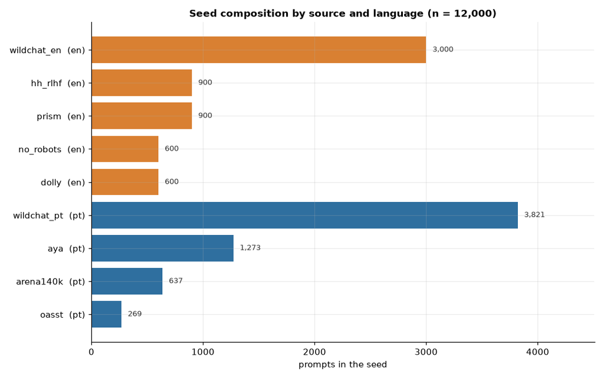

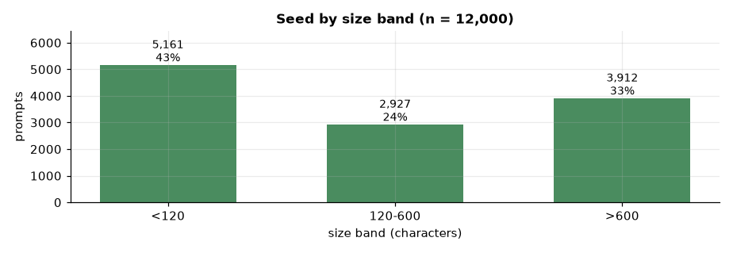

```
native_category present on 1,200 of 12,000 rows (10.0%) — the other 10,800 come from sources that publish no category at all
```

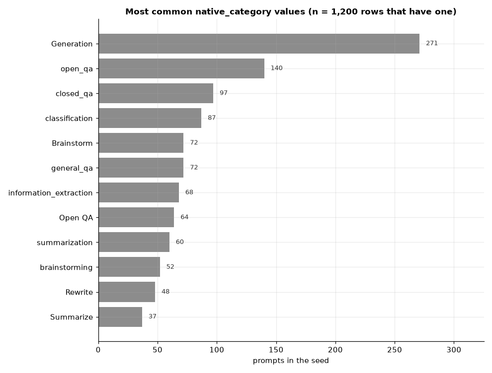

```
native category -> task_type mappings on disk: dolly, no_robots
    dolly: 8 native categories, 0 mapped to null (-)
        note: Nenhuma categoria sem correspondência limpa nesta fonte — as 8 mapeiam. Cuidado ao acrescentar: só entra aqui categoria cuja definição na fonte caiba INTEIRA num task_type; havendo bifurcação (o caso de 'Generation' no n
    no_robots: 10 native categories, 1 mapped to null (Generation)
        note: 'Generation' (4.560 linhas, 46% da fonte) fica NULL de propósito: a fonte usa uma categoria só para 'gerar texto', e a taxonomia v1.0 divide isso em geracao-criativa (ficção/arte) e redacao-pratica (e-mail, post, currícu
```

```python
if SEED_PARQUET.exists():
    # NUNCA a coluna `text`: ela carrega o prompt inteiro e é o motivo de a
    # semente ser gitignorada. Ler só o metadado é a política, não uma economia.
    colunas = ["uid", "lang", "source", "n_chars", "native_category", "bucket"]
    t = pq.read_table(SEED_PARQUET, columns=colunas)
    print(f"seed.parquet: {t.num_rows:,} rows, columns read = {colunas}")
    print(f"(the file also has a `text` column, {pq.ParquetFile(SEED_PARQUET).metadata.num_rows:,} "
          f"prompt bodies, which this notebook does not load)")

    langs = t.column("lang").to_pylist()
    fontes = t.column("source").to_pylist()
    buckets = t.column("bucket").to_pylist()
    nativos = t.column("native_category").to_pylist()

    por_lang = Counter(langs)
    print("\nby language: " + ", ".join(f"{k}={v:,}" for k, v in sorted(por_lang.items())))

    par = Counter(zip(fontes, langs, strict=True))
    ordem = sorted(par, key=lambda p: (p[1], -par[p]))
    fig, ax = plt.subplots(figsize=(9.5, 0.44 * len(ordem) + 2.0))
    rot = [f"{f}  ({lg})" for f, lg in ordem]
    val = [par[p] for p in ordem]
    cores = [AZUL if lg == "pt" else LARANJA for _, lg in ordem]
    ax.barh(rot, val, color=cores)
    anotar(ax, val, range(len(rot)), dx=max(val) * 0.015)
    ax.invert_yaxis()
    ax.set_xlim(0, max(val) * 1.18)
    ax.set_xlabel("prompts in the seed")
    ax.set_title(f"Seed composition by source and language (n = {t.num_rows:,})")
    plt.tight_layout()
    mostrar(fig, "Horizontal bar chart of seed composition, one bar per source and language pair, coloured by language.")

    # ---- faixas de tamanho
    pb = Counter(buckets)
    ordem_b = sorted(pb, key=lambda b: min(
        n for n, bb in zip(t.column("n_chars").to_pylist(), buckets, strict=True)
        if bb == b))
    fig, ax = plt.subplots(figsize=(8.4, 2.9))
    val = [pb[b] for b in ordem_b]
    barras = ax.bar(ordem_b, val, color=VERDE, width=0.6)
    for b, v in zip(barras, val, strict=True):
        ax.annotate(f"{v:,}\n{v / t.num_rows:.0%}", (b.get_x() + b.get_width() / 2, v),
                    ha="center", va="bottom", fontsize=9)
    ax.set_ylim(0, max(val) * 1.25)
    ax.set_ylabel("prompts")
    ax.set_xlabel("size band (characters)")
    ax.set_title(f"Seed by size band (n = {t.num_rows:,})")
    plt.tight_layout()
    mostrar(fig, "Bar chart of the seed split into character-size bands, each bar labelled with its count and share.")

    # ---- cobertura de native_category
    com = sum(1 for x in nativos if x)
    print(f"\nnative_category present on {com:,} of {t.num_rows:,} rows "
          f"({com / t.num_rows:.1%}) — the other {t.num_rows - com:,} come from sources "
          f"that publish no category at all")
    top = Counter(x for x in nativos if x).most_common(12)
    if top:
        fig, ax = plt.subplots(figsize=(9, 0.42 * len(top) + 1.8))
        rot = [k for k, _ in top]
        val = [v for _, v in top]
        ax.barh(rot, val, color=CINZA)
        anotar(ax, val, range(len(rot)), dx=max(val) * 0.02)
        ax.invert_yaxis()
        ax.set_xlim(0, max(val) * 1.2)
        ax.set_xlabel("prompts in the seed")
        ax.set_title(f"Most common native_category values (n = {com:,} rows that have one)")
        plt.tight_layout()
        mostrar(fig, "Horizontal bar chart of the most common native_category values across the seed rows that carry one.")

    # ---- os mapeamentos, e o buraco proposital
    mapeamentos = sorted(paths.MAPPINGS.glob("*.json")) if paths.MAPPINGS.exists() else []
    print(f"\nnative category -> task_type mappings on disk: "
          f"{', '.join(p.stem for p in mapeamentos) or '(none)'}")
    for p in mapeamentos:
        mp = json.loads(p.read_text(encoding="utf-8"))
        regras = mp.get("map") or mp.get("mapping") or {}
        nulos = [k for k, v in regras.items() if v is None]
        print(f"    {p.stem}: {len(regras)} native categories, "
              f"{len(nulos)} mapped to null ({', '.join(nulos) or '-'})")
        if mp.get("_unmapped_note"):
            print(f"        note: {mp['_unmapped_note'][:220]}")
else:
    print("skipped — labeling/seed/seed.parquet absent (run `pf make-seed`)")
```

### The stratification report, as the stage wrote it

`strata.txt` is written by s07 next to the seed. It is the human-readable form of the same allocation, including the per-source size-band breakdown in `taken/available` form — which is where an over-drawn band would show up.

It is reproduced **verbatim, in Portuguese**, and so are the `_note` fields of the mapping files above. That is the project's language convention rather than an oversight: code comments, docstrings, CLI messages and internal stage artifacts are pt-BR, while everything *delivered* — dataset card, quality report, audit, and these notebooks — is English. Translating an internal artifact on the way into a report would mean the report quotes something that does not exist on disk under that wording.

```python
if STRATA_TXT.exists():
    print(STRATA_TXT.read_text(encoding="utf-8"))
else:
    print("skipped — labeling/seed/strata.txt absent")
```

```
# s07 — amostra-semente estratificada (fonte x faixa de tamanho)
# universo: data/final/universe.parquet (159733 linhas)
# rng_seed=42  size=12000  pt_share=0.5  bucket_edges=[120, 600]  bucket_floor=0.1

## pt — alvo 6000
fonte               cota  disponível   final   faixas
wildchat_pt         3600       35841    3821   <120=1054/9100 120-600=805/5872 >600=1962/20869
aya                 1200        6282    1273   <120=884/5135 120-600=252/951 >600=137/196
oasst                600         269     269   <120=184/184 120-600=83/83 >600=2/2
arena140k            600        1242     637   <120=339/712 120-600=204/395 >600=94/135
redistribuição de déficit:
  - rodada 1: oasst cede 331 (cota 600, disponível 269)
  - rodada 1: wildchat_pt recebe +221
  - rodada 1: aya recebe +73
  - rodada 1: arena140k recebe +37

## en — alvo 6000
fonte               cota  disponível   final   faixas
wildchat_en         3000       66985    3000   <120=778/15334 120-600=879/18529 >600=1343/33122
no_robots            600        9949     600   <120=219/3759 120-600=260/4711 >600=121/1479
dolly                600       14416     600   <120=322/8943 120-600=127/2326 >600=151/3147
hh_rlhf              900       14878     900   <120=649/13062 120-600=159/1689 >600=92/127
prism                900        7562     900   <120=732/6758 120-600=158/794 >600=10/10

## faixas de tamanho na semente
<120            5161
120-600         2927
>600            3912

## lotes: 155 de 80 itens (77 novos + 3 de calibração ocultos)
calibração: batch_0000 com 100 itens (gold_pending — revisar à mão e importar com `pf labels gold`)
```

## 4. The labels the campaign produced

Stage s08 merges the agent labels, the hand-revised gold and the sources' native categories into `data/final/seed_labels.parquet`, with precedence **manual > agent > native**. With that file on disk, the class distribution over the taxonomy is the first thing to look at: the 16 task types and 16 domains are not expected to be uniform, but a class that is empty in the seed is a class the downstream classifier cannot learn.

Read the `by precedence` line at the bottom with care. The native categories are the largest group by count and the least trustworthy by construction — they are a mapping from each source's own vocabulary, not an observation. Stage s09 measured exactly that: training with them scored **worse** than training without (macro-F1 0.53 against 0.58), so the classifier that was actually shipped ignores them. They stay in this file because the merge records what each source claims; what the model believes is a separate decision.

```
seed_labels.parquet: 25,717 rows, columns: ['uid', 'task_type', 'domain', 'quality', 'nsfw', 'label_method', 'label_weight', 'batch_id']
```

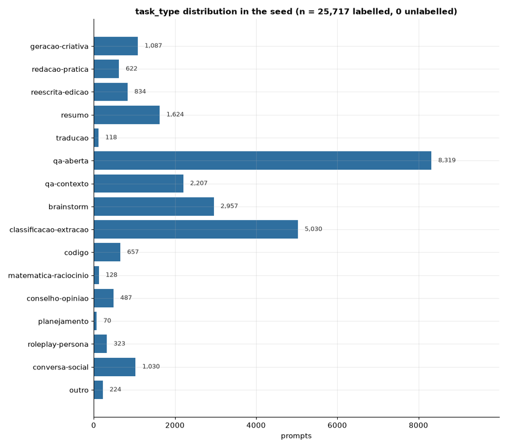

```
task_type: 16 of 16 classes populated; empty = none
```

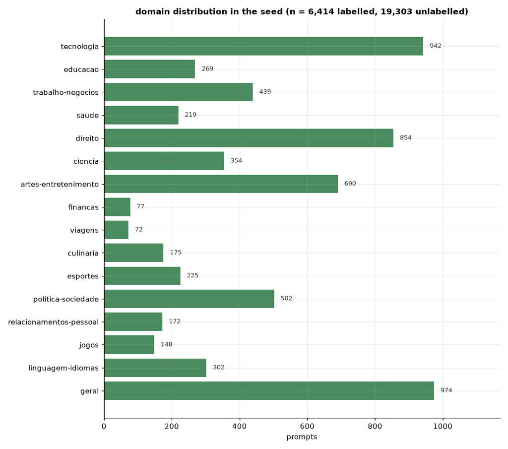

```
domain: 16 of 16 classes populated; empty = none

by precedence: native=19,303, agent=6,314, manual=100
```

```python
if SEED_LABELS.exists():
    t = pq.read_table(SEED_LABELS)
    print(f"seed_labels.parquet: {t.num_rows:,} rows, columns: {t.schema.names}")
    for eixo in ("task_type", "domain"):
        if eixo not in t.schema.names:
            continue
        vals = t.column(eixo).to_pylist()
        cont = Counter(v for v in vals if v)
        nulos = sum(1 for v in vals if not v)
        classes = list(taxonomia[eixo])           # ordem da taxonomia, zeros incluídos
        val = [cont.get(c, 0) for c in classes]
        fig, ax = plt.subplots(figsize=(9.5, 0.4 * len(classes) + 2.0))
        ax.barh(classes, val, color=AZUL if eixo == "task_type" else VERDE)
        anotar(ax, val, range(len(classes)), dx=(max(val) or 1) * 0.02)
        ax.invert_yaxis()
        ax.set_xlim(0, (max(val) or 1) * 1.2)
        ax.set_xlabel("prompts")
        ax.set_title(f"{eixo} distribution in the seed "
                     f"(n = {t.num_rows - nulos:,} labelled, {nulos:,} unlabelled)")
        plt.tight_layout()
        mostrar(fig, "Horizontal bar chart of the label distribution across the taxonomy axis, drawn over every class in taxonomy order so that empty classes stay visible.")
        vazias = [c for c in classes if not cont.get(c)]
        print(f"{eixo}: {len(classes) - len(vazias)} of {len(classes)} classes populated; "
              f"empty = {', '.join(vazias) or 'none'}")
    if "label_method" in t.schema.names:
        print("\nby precedence: " +
              ", ".join(f"{k}={v:,}" for k, v in
                        Counter(t.column("label_method").to_pylist()).most_common()))
else:
    print("data/final/seed_labels.parquet has NOT been produced yet.")
    print()
    print("It is the output of stage s08, which needs the campaign to have run:")
    print("    1. pf labels gold --file <hand-revised calibration>.jsonl")
    print("    2. run the campaign (skill `rotular-prompts`, or pf labels next / submit)")
    print("    3. pf merge-labels")
    print()
    print("Until then, `task_type`, `domain`, `quality` and `nsfw` are NULL for 100% of the")
    print("corpus, and the curation interface disables those facets with an explanation")
    print("rather than hiding them — a filter group that vanishes reads as a bug.")
    classes = list(taxonomia["task_type"])
    fig, ax = plt.subplots(figsize=(9.5, 0.4 * len(classes) + 2.0))
    ax.barh(classes, [0] * len(classes), color=CINZA)
    ax.set_xlim(0, 1)
    ax.invert_yaxis()
    ax.set_xlabel("prompts")
    ax.set_title(f"task_type distribution — awaiting the campaign "
                 f"(n = 0 of {len(classes)} classes populated)")
    ax.annotate("every class at zero: not measured, not measured as empty",
                xy=(0.5, 0.5), xycoords="axes fraction", ha="center",
                fontsize=10, color=CINZA, style="italic")
    plt.tight_layout()
    mostrar(fig, "Horizontal bar chart of the task_type taxonomy with every class at zero, marking that the labels have not been produced rather than measured as empty.")
```

## 5. Near-duplicate removal, validated against its own output

This stage **has** run, and its output is on disk. The map `data/final/dedup_near_map.parquet` records one row per discarded prompt: which canonical it was folded into, and the cosine and Jaccard measured **against that canonical**.

### Why a pairwise recheck exists at all

Grouping is done with union-find, which is transitive: confirm A~B and B~C and A lands in the same component as C **without the two ever having been compared**. That is not a theoretical worry — it was measured on the first run of this stage and it was discarding good rows. The fix (`[dedup] near_pairwise = true`) rechecks every member **against the canonical** on all three criteria, and whoever fails stays in the universe.

The historical measurement, from the first execution of s06 and reported in the project's engineering notes: of 44,333 discards, **27% (11,964) had cosine < 0.985 against their own group's canonical** and 13.4% had Jaccard < 0.65. Those figures describe a run whose artifacts are not the ones on disk now and are cited here as history, with attribution, not recomputed below.

What *is* recomputed below is the invariant that the pairwise recheck guarantees, over the map that is actually on disk: **every single discarded row clears both thresholds against its canonical.**

### And why cosine alone must never decide

The embedding model truncates at 512 tokens (~1,900 characters in pt, ~2,100 in en), so two texts sharing a long header produce identical vectors while diverging completely after the cut. A real cluster of 2,088 rows shared 8,180 characters of prefix — one asked for a forecast, another for a travel itinerary. Jaccard is the criterion that sees the whole text.

```python
import tomllib

cfg = tomllib.loads(paths.SETTINGS_TOML.read_text(encoding="utf-8"))
lim = cfg.get("dedup", {})
COS_MIN, JAC_MIN = lim.get("near_cosine"), lim.get("near_jaccard")
print(f"thresholds from config/settings.toml [dedup]: near_cosine = {COS_MIN}, "
      f"near_jaccard = {JAC_MIN}, near_len_ratio = {lim.get('near_len_ratio')}, "
      f"near_pairwise = {lim.get('near_pairwise')}")
print("(thresholds live in the config file, never hardcoded — it is what makes the stages "
      "replayable)")

# ---- funil por METADATA de parquet: só o footer é lido, nenhuma linha carregada.
print("\nPipeline funnel, read from parquet metadata (no row is loaded):")
etapas = [("raw -> s01 normalize", NORMALIZED), ("s02 language + variant", LANG_PARQUET),
          ("s04 exact dedup", DEDUP1), ("s06 near dedup -> universe", UNIVERSE)]
funil = []
for rotulo, caminho in etapas:
    if caminho.exists():
        n = pq.ParquetFile(caminho).metadata.num_rows
        funil.append((rotulo, caminho.name, n))
        print(f"    {rotulo:<30} {caminho.name:<22} {n:>10,}")
    else:
        print(f"    {rotulo:<30} {caminho.name:<22} {'ABSENT':>10}")

if NEAR_MAP.exists() and DEDUP1.exists() and UNIVERSE.exists():
    n_in = pq.ParquetFile(DEDUP1).metadata.num_rows
    n_out = pq.ParquetFile(UNIVERSE).metadata.num_rows
    n_near = pq.ParquetFile(NEAR_MAP).metadata.num_rows
    resto = n_in - n_near - n_out
    print(f"\n    {n_in:,} into s06")
    print(f"  - {n_near:,} near-duplicates (dedup_near_map.parquet)")
    print(f"  - {resto:,} dropped by the s06 language recheck")
    print(f"  = {n_out:,} in final/universe.parquet")
    assert n_in - n_near - resto == n_out
    print("\nThe language recheck runs BEFORE grouping and uses a window SMALLER than s02's")
    print(f"([dedup] lang_recheck_head_chars = {lim.get('lang_recheck_head_chars')}): a long")
    print("pasted payload drowns the instruction, and the language of a prompt is the")
    print("language of the INSTRUCTION, not of the material pasted underneath it.")
```

```
thresholds from config/settings.toml [dedup]: near_cosine = 0.985, near_jaccard = 0.65, near_len_ratio = 2.0, near_pairwise = True
(thresholds live in the config file, never hardcoded — it is what makes the stages replayable)

Pipeline funnel, read from parquet metadata (no row is loaded):
    raw -> s01 normalize           normalized.parquet        214,946
    s02 language + variant         lang.parquet              201,704
    s04 exact dedup                dedup1.parquet            189,087
    s06 near dedup -> universe     universe.parquet          159,733

    189,087 into s06
  - 27,139 near-duplicates (dedup_near_map.parquet)
  - 2,215 dropped by the s06 language recheck
  = 159,733 in final/universe.parquet

The language recheck runs BEFORE grouping and uses a window SMALLER than s02's
([dedup] lang_recheck_head_chars = 250): a long
pasted payload drowns the instruction, and the language of a prompt is the
language of the INSTRUCTION, not of the material pasted underneath it.
```

```
discarded near-duplicates on disk: 27,139
  cosine  >= 0.985: 27,139 of 27,139  (100.0000%)
  jaccard >= 0.65 : 27,139 of 27,139  (100.0000%)
  BOTH               : 27,139 of 27,139  (100.0000%)

INVARIANT: every discarded row clears both thresholds against its canonical — HOLDS.
```

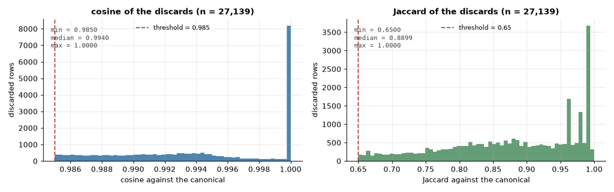

```
Both distributions are hard-clipped at the threshold, which is the visual form of
the invariant: nothing below the line was ever discarded.

27,139 discards folded into 7,278 distinct canonicals (3.7 discards per canonical on average)
by language: en=19,760, pt=7,379

The canonical never changes when members are spared: `dedup.choose_canonical` is
a min over the group and validation only ever removes non-canonical rows — the
minimum of a subset that still contains the minimum is the same minimum. That is
what makes validating in a single pass correct, and it is an invariant, not luck.
```

```python
if NEAR_MAP.exists():
    t = pq.read_table(NEAR_MAP)
    cos = t.column("cosine").to_numpy()
    jac = t.column("jaccard").to_numpy()
    n = len(cos)
    ok_cos = int((cos >= COS_MIN).sum())
    ok_jac = int((jac >= JAC_MIN).sum())
    ok_ambos = int(((cos >= COS_MIN) & (jac >= JAC_MIN)).sum())

    print(f"discarded near-duplicates on disk: {n:,}")
    print(f"  cosine  >= {COS_MIN}: {ok_cos:,} of {n:,}  ({ok_cos / n:.4%})")
    print(f"  jaccard >= {JAC_MIN} : {ok_jac:,} of {n:,}  ({ok_jac / n:.4%})")
    print(f"  BOTH               : {ok_ambos:,} of {n:,}  ({ok_ambos / n:.4%})")
    print("\nINVARIANT: every discarded row clears both thresholds against its canonical — "
          + ("HOLDS." if ok_ambos == n else f"VIOLATED by {n - ok_ambos:,} row(s)."))

    fig, axes = plt.subplots(1, 2, figsize=(11.5, 3.6))
    for ax, dados, minimo, nome, cor in (
        (axes[0], cos, COS_MIN, "cosine", AZUL),
        (axes[1], jac, JAC_MIN, "Jaccard", VERDE),
    ):
        ax.hist(dados, bins=60, color=cor, alpha=0.85)
        ax.axvline(minimo, color=VERMELHO, linestyle="--", linewidth=1.4,
                   label=f"threshold = {minimo}")
        ax.set_xlabel(f"{nome} against the canonical")
        ax.set_ylabel("discarded rows")
        ax.set_title(f"{nome} of the discards (n = {n:,})")
        ax.legend(frameon=False, fontsize=8.5)
        ax.annotate(f"min = {dados.min():.4f}\nmedian = {sorted(dados)[len(dados) // 2]:.4f}\n"
                    f"max = {dados.max():.4f}",
                    xy=(0.03, 0.95), xycoords="axes fraction", va="top",
                    fontsize=8.5, color="#444", family="monospace")
    plt.tight_layout()
    mostrar(fig, "Two histograms side by side, cosine and Jaccard similarity of every discarded near-duplicate against its canonical, each with a dashed line at the configured threshold and the distribution hard-clipped at it.")

    print("Both distributions are hard-clipped at the threshold, which is the visual form of")
    print("the invariant: nothing below the line was ever discarded.")

    canonicos = len(set(t.column("canonical_uid").to_pylist()))
    por_lang = Counter(t.column("lang").to_pylist())
    print(f"\n{n:,} discards folded into {canonicos:,} distinct canonicals "
          f"({n / canonicos:.1f} discards per canonical on average)")
    print("by language: " + ", ".join(f"{k}={v:,}" for k, v in por_lang.most_common()))
    print("\nThe canonical never changes when members are spared: `dedup.choose_canonical` is")
    print("a min over the group and validation only ever removes non-canonical rows — the")
    print("minimum of a subset that still contains the minimum is the same minimum. That is")
    print("what makes validating in a single pass correct, and it is an invariant, not luck.")
else:
    print("skipped — data/final/dedup_near_map.parquet absent (run `pf run s06`)")
```

## 6. Exact duplicates, and the tiebreak nobody sees

Stage s04 folds byte-identical normalized texts by `hash_norm`. Which row survives is **not** arbitrary: the tiebreak is the order of the sections in `config/sources.toml`. That is the reason a config file's *ordering* is documented as load-bearing — the same corpus with the sections shuffled would keep a different row from each duplicate family, and the licence carried by the surviving row would change with it.

The cross-source column below is where that matters: when a duplicate spans two sources, the tiebreak decides which licence the corpus keeps.

```
exact duplicates removed: 12,617
  same source as the canonical : 11,987 (95.0%)
  cross-source                 : 630 (5.0%)   <- here the sources.toml order decides which licence survives
```

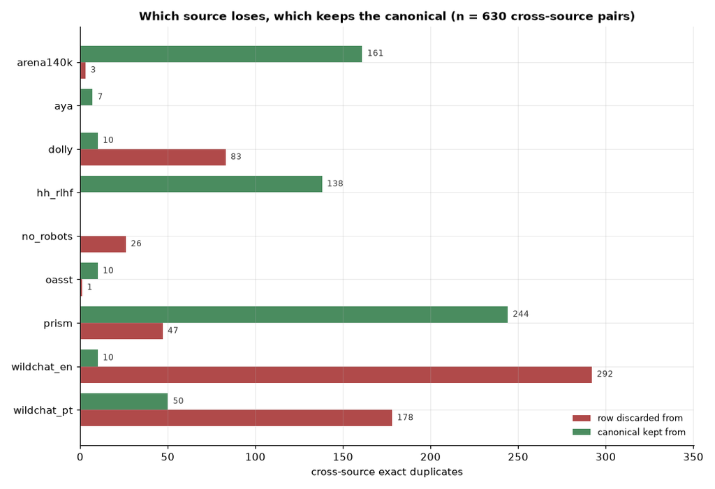

```
12,617 discards folded into 6,009 distinct canonicals
Note the empty-key case that does NOT group: norm_for_hash('!!!') == '', so every
punctuation-only prompt shares the sha256 of the empty string. s04 lets those rows
through whole rather than collapsing them into one.
```

```python
if EXACT_MAP.exists():
    t = pq.read_table(EXACT_MAP)
    n = t.num_rows
    src = t.column("source").to_pylist()
    can = t.column("canonical_source").to_pylist()
    cruzados = [(a, b) for a, b in zip(src, can, strict=True) if a != b]
    print(f"exact duplicates removed: {n:,}")
    print(f"  same source as the canonical : {n - len(cruzados):,} "
          f"({(n - len(cruzados)) / n:.1%})")
    print(f"  cross-source                 : {len(cruzados):,} ({len(cruzados) / n:.1%})"
          "   <- here the sources.toml order decides which licence survives")

    perdedores = Counter(a for a, _ in cruzados)
    vencedores = Counter(b for _, b in cruzados)
    if cruzados:
        fontes = sorted(set(perdedores) | set(vencedores))
        y = range(len(fontes))
        alt = 0.38
        fig, ax = plt.subplots(figsize=(9.5, 0.5 * len(fontes) + 2.0))
        v1 = [perdedores.get(f, 0) for f in fontes]
        v2 = [vencedores.get(f, 0) for f in fontes]
        ax.barh([i + alt / 2 for i in y], v1, alt, color=VERMELHO, label="row discarded from")
        ax.barh([i - alt / 2 for i in y], v2, alt, color=VERDE, label="canonical kept from")
        for i, (a, b) in enumerate(zip(v1, v2, strict=True)):
            if a:
                ax.annotate(f"{a:,}", (a + max(v1 + v2) * 0.01, i + alt / 2),
                            va="center", fontsize=8, color="#333")
            if b:
                ax.annotate(f"{b:,}", (b + max(v1 + v2) * 0.01, i - alt / 2),
                            va="center", fontsize=8, color="#333")
        ax.set_yticks(list(y), fontes)
        ax.invert_yaxis()
        ax.set_xlim(0, max(v1 + v2) * 1.2)
        ax.set_xlabel("cross-source exact duplicates")
        ax.set_title(f"Which source loses, which keeps the canonical "
                     f"(n = {len(cruzados):,} cross-source pairs)")
        ax.legend(frameon=False, fontsize=8.5, loc="lower right")
        plt.tight_layout()
        mostrar(fig, "Horizontal bar chart pairing, per source, how many rows it lost to a cross-source exact duplicate against how many canonicals it kept.")
    else:
        print("\n  no cross-source exact duplicate in this run — every family stayed inside "
              "one source, so the tiebreak never had to choose a licence.")

    familias = len(set(t.column("canonical_uid").to_pylist()))
    print(f"\n{n:,} discards folded into {familias:,} distinct canonicals")
    print("Note the empty-key case that does NOT group: norm_for_hash('!!!') == '', so every")
    print("punctuation-only prompt shares the sha256 of the empty string. s04 lets those rows")
    print("through whole rather than collapsing them into one.")
else:
    print("skipped — data/interim/dedup_exact_map.parquet absent (run `pf run s04`)")
```

## 7. What this cannot claim yet

- **The campaign is partial, and stopped on purpose.** The batches still `pending` were not abandoned mid-run: doubling the labels moved the classifier's macro-F1 on `task_type` by about one hundredth, so finishing them buys a complete seed, not a better model. The panels above describe the ledger as it stands, and the state machine bar shows exactly how much of it has closed.
- **Agreement here is not inter-annotator agreement.** Every score above compares one annotator against a **hand-revised key**, on the `task_type` and `domain` of 3 gold items — six comparisons per batch. That measures conformity to one human's judgement, not the reproducibility of the judgement itself. Two independent annotators labelling the same items, and a chance-corrected coefficient over them, is a different measurement that this campaign has not made.
- **And it measures *applied guidance*, not spontaneous agreement.** The boundaries the taxonomy leaves open — `redacao-pratica` against `qa-aberta`, `resumo` against `qa-contexto`, `brainstorm` against `conselho-opiniao` — were written into the annotator's briefing **after** being read off the gold. From that point on, the number says "the annotator applied the convention", which is a weaker claim than "the annotator agreed unprompted", and the two must not be reported as if they were the same.
- **The taxonomy axes are not equally covered, and two of them are effectively empty.** `task_type` and `domain` are populated for most of the universe — partly by these labels, mostly by a classifier trained on them, with abstention declared per row. `quality` was trained, measured and **deliberately not applied**; `nsfw` had too few positives to train at all. Any claim about the quality or safety composition of this corpus is unsupported.
- **The near-duplicate invariant is a consistency check, not a quality judgement.** It proves that every discarded row met the configured thresholds against its canonical. It does **not** prove the thresholds are the right ones — that is a human decision, which is why `pf report dedup-sample` writes 50 pairs to a file for a person to read.
- **Transitivity is mitigated, not eliminated.** Two spared members may still be duplicates of each other. Re-grouping them would require running union-find to a fixed point with the canonical shifting mid-flight; the project deliberately prefers letting a few near pairs through to discarding good rows by transitivity. The trade is a choice, and it is recorded as one.
- **The historical 44,333 / 27% figures are not reproducible from the artifacts on disk.** They describe the first execution of s06, before the pairwise recheck existed. They are cited as history, attributed as such, and no chart above is drawn from them.

### Licence and provenance of this page

`labeling/seed/seed.parquet` and `labeling/batches/*.json` carry full prompt bodies and are gitignored for that reason; the sources behind them include CC-BY-NC-4.0 material. This notebook reads the seed's **metadata columns only** and never loads a batch file, and the rendered page contains **counts and distributions exclusively** — no prompt text of any length, from any source. The hand-revised gold labels are reported as a count and never printed: they are the key every batch is scored against. Per-row licence and attribution for actual data exports are emitted by `prompt_factory.export`, resolved from `config/sources.toml`.